# FINAL ASSIGNMENT

## DATA PROCESSING AND PRELIMINARY EXPLORATION

```python
# Importing the necessary Libraries

import numpy as np
import pandas as pd
import seaborn as sns
import matplotlib.pyplot as plt

%matplotlib inline

plt.style.use('fivethirtyeight')
```

```python
import warnings
warnings.filterwarnings('ignore')
```

```python
# Reading the CSV File

amz_df = pd.read_csv('amazonbestsellers.csv')
```

```python
# Viewing the first 10 rows of the dataset

amz_df.head(10)
```

|  | Name | Author | User Rating | Reviews | Price | Year | Genre |
| --- | --- | --- | --- | --- | --- | --- | --- |
| 0 | 10-Day Green Smoothie Cleanse | JJ Smith | 4.7 | 17350 | 8 | 2016 | Non Fiction |
| 1 | 11/22/63: A Novel | Stephen King | 4.6 | 2052 | 22 | 2011 | Fiction |
| 2 | 12 Rules for Life: An Antidote to Chaos | Jordan B. Peterson | 4.7 | 18979 | 15 | 2018 | Non Fiction |
| 3 | 1984 (Signet Classics) | George Orwell | 4.7 | 21424 | 6 | 2017 | Fiction |
| 4 | 5,000 Awesome Facts (About Everything!) (Natio... | National Geographic Kids | 4.8 | 7665 | 12 | 2019 | Non Fiction |
| 5 | A Dance with Dragons (A Song of Ice and Fire) | George R. R. Martin | 4.4 | 12643 | 11 | 2011 | Fiction |
| 6 | A Game of Thrones / A Clash of Kings / A Storm... | George R. R. Martin | 4.7 | 19735 | 30 | 2014 | Fiction |
| 7 | A Gentleman in Moscow: A Novel | Amor Towles | 4.7 | 19699 | 15 | 2017 | Fiction |
| 8 | A Higher Loyalty: Truth, Lies, and Leadership | James Comey | 4.7 | 5983 | 3 | 2018 | Non Fiction |
| 9 | A Man Called Ove: A Novel | Fredrik Backman | 4.6 | 23848 | 8 | 2016 | Fiction |

```python
# Viewing the last 10 rows of the dataset

amz_df.tail(10)
```

|  | Name | Author | User Rating | Reviews | Price | Year | Genre |
| --- | --- | --- | --- | --- | --- | --- | --- |
| 540 | Wonder | R. J. Palacio | 4.8 | 21625 | 9 | 2013 | Fiction |
| 541 | Wonder | R. J. Palacio | 4.8 | 21625 | 9 | 2014 | Fiction |
| 542 | Wonder | R. J. Palacio | 4.8 | 21625 | 9 | 2015 | Fiction |
| 543 | Wonder | R. J. Palacio | 4.8 | 21625 | 9 | 2016 | Fiction |
| 544 | Wonder | R. J. Palacio | 4.8 | 21625 | 9 | 2017 | Fiction |
| 545 | Wrecking Ball (Diary of a Wimpy Kid Book 14) | Jeff Kinney | 4.9 | 9413 | 8 | 2019 | Fiction |
| 546 | You Are a Badass: How to Stop Doubting Your Gr... | Jen Sincero | 4.7 | 14331 | 8 | 2016 | Non Fiction |
| 547 | You Are a Badass: How to Stop Doubting Your Gr... | Jen Sincero | 4.7 | 14331 | 8 | 2017 | Non Fiction |
| 548 | You Are a Badass: How to Stop Doubting Your Gr... | Jen Sincero | 4.7 | 14331 | 8 | 2018 | Non Fiction |
| 549 | You Are a Badass: How to Stop Doubting Your Gr... | Jen Sincero | 4.7 | 14331 | 8 | 2019 | Non Fiction |

```python
# Getting the value of the total rows and columns in the dataset

print("There are {} rows and {} columns in the dataset.".format(amz_df.shape[0], amz_df.shape[1]))
```

```
There are 550 rows and 7 columns in the dataset.
```

```python
# Getting a concise summary of the dataframe

amz_df.info()
```

```
<class 'pandas.core.frame.DataFrame'>
RangeIndex: 550 entries, 0 to 549
Data columns (total 7 columns):
 #   Column       Non-Null Count  Dtype
---  ------       --------------  -----
 0   Name         550 non-null    object
 1   Author       550 non-null    object
 2   User Rating  550 non-null    float64
 3   Reviews      550 non-null    int64
 4   Price        550 non-null    int64
 5   Year         550 non-null    int64
 6   Genre        550 non-null    object
dtypes: float64(1), int64(3), object(3)
memory usage: 30.2+ KB
```

```python
# Checking for missing values

amz_df.isnull().sum()
```

```
Name           0
Author         0
User Rating    0
Reviews        0
Price          0
Year           0
Genre          0
dtype: int64
```

```python
# Checking for duplicate values

amz_df.duplicated().sum()
```

```
0
```

```python
# Getting more statistics of the dataframe

amz_df.describe()
```

|  | User Rating | Reviews | Price | Year |
| --- | --- | --- | --- | --- |
| count | 550.000000 | 550.000000 | 550.000000 | 550.000000 |
| mean | 4.618364 | 11953.281818 | 13.100000 | 2014.000000 |
| std | 0.226980 | 11731.132017 | 10.842262 | 3.165156 |
| min | 3.300000 | 37.000000 | 0.000000 | 2009.000000 |
| 25% | 4.500000 | 4058.000000 | 7.000000 | 2011.000000 |
| 50% | 4.700000 | 8580.000000 | 11.000000 | 2014.000000 |
| 75% | 4.800000 | 17253.250000 | 16.000000 | 2017.000000 |
| max | 4.900000 | 87841.000000 | 105.000000 | 2019.000000 |

```python
# Range of prices of the books

np.sort(amz_df['Price'].unique())
```

```
array([  0,   1,   2,   3,   4,   5,   6,   7,   8,   9,  10,  11,  12,
        13,  14,  15,  16,  17,  18,  19,  20,  21,  22,  23,  24,  25,
        27,  28,  30,  32,  36,  39,  40,  42,  46,  52,  53,  54,  82,
       105])
```

Well, zero price would mean that Amazon distributed those books for free, lets see these books labeled with zero price.

```python
# Books with price = $0

amz_df[amz_df['Price'] == 0]
```

|  | Name | Author | User Rating | Reviews | Price | Year | Genre |
| --- | --- | --- | --- | --- | --- | --- | --- |
| 42 | Cabin Fever (Diary of a Wimpy Kid, Book 6) | Jeff Kinney | 4.8 | 4505 | 0 | 2011 | Fiction |
| 71 | Diary of a Wimpy Kid: Hard Luck, Book 8 | Jeff Kinney | 4.8 | 6812 | 0 | 2013 | Fiction |
| 116 | Frozen (Little Golden Book) | RH Disney | 4.7 | 3642 | 0 | 2014 | Fiction |
| 193 | JOURNEY TO THE ICE P | RH Disney | 4.6 | 978 | 0 | 2014 | Fiction |
| 219 | Little Blue Truck | Alice Schertle | 4.9 | 1884 | 0 | 2014 | Fiction |
| 358 | The Constitution of the United States | Delegates of the Constitutional | 4.8 | 2774 | 0 | 2016 | Non Fiction |
| 381 | The Getaway | Jeff Kinney | 4.8 | 5836 | 0 | 2017 | Fiction |
| 461 | The Short Second Life of Bree Tanner: An Eclip... | Stephenie Meyer | 4.6 | 2122 | 0 | 2010 | Fiction |
| 505 | To Kill a Mockingbird | Harper Lee | 4.8 | 26234 | 0 | 2013 | Fiction |
| 506 | To Kill a Mockingbird | Harper Lee | 4.8 | 26234 | 0 | 2014 | Fiction |
| 507 | To Kill a Mockingbird | Harper Lee | 4.8 | 26234 | 0 | 2015 | Fiction |
| 508 | To Kill a Mockingbird | Harper Lee | 4.8 | 26234 | 0 | 2016 | Fiction |

## DATA VISUALIZATION ANALYSIS

#### What is the Rating Distribution for the Books?

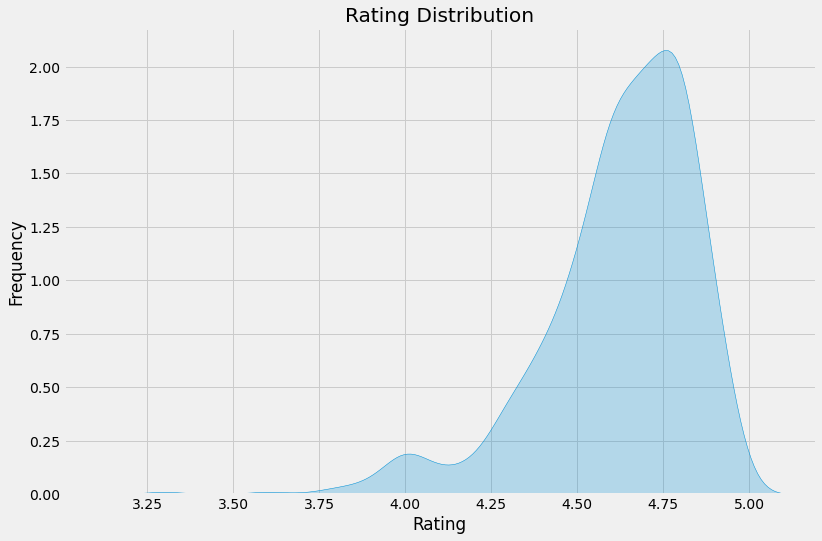

```python
# Ratings Distribution


fig, ax = plt.subplots(figsize = (12,8))
sns.kdeplot(amz_df['User Rating'], shade = True, ax = ax)
ax.set_xlabel('Rating')
ax.set_ylabel('Frequency')
ax.set_title('Rating Distribution')
fig.show()
```

- Most of the ratings for bestselling books are in the range of 4.5 - 4.9
- The peak of the ratings is at about 4.75

#### What is the Genre Distribution for the Books?

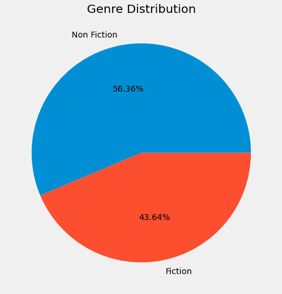

```python
# Genre Distribution

fig, ax = plt.subplots(figsize = (12,8))

ax.pie(amz_df['Genre'].value_counts(), autopct = '%1.2f%%', labels = amz_df['Genre'].value_counts().index)
ax.set_title('Genre Distribution')
```

- Non-Fiction books are more popular, although the difference is not too substantial

#### What is the Price Distribuition for the Books?

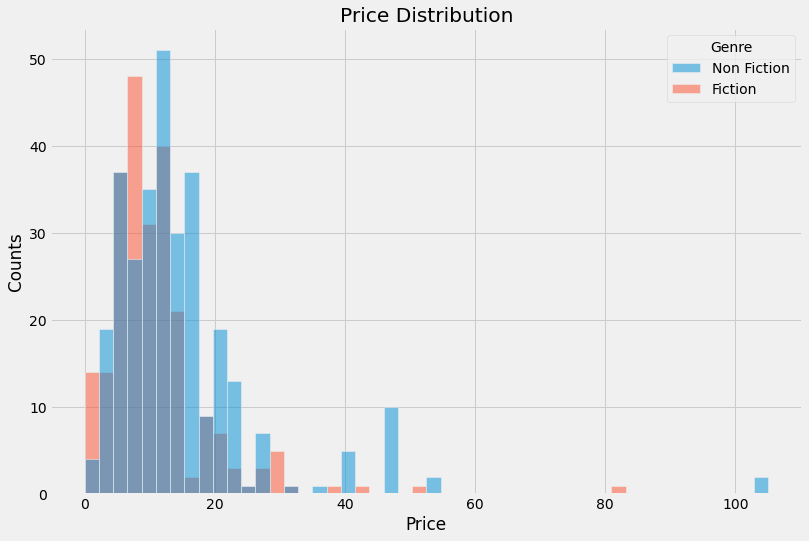

```python
# Price Distribution

fig, ax = plt.subplots(figsize = (12,8))
sns.histplot(x = 'Price', hue = 'Genre', data = amz_df, ax = ax)
ax.set_xlabel('Price')
ax.set_ylabel('Counts')
ax.set_title('Price Distribution')
fig.show()
```

- Most of the books of both the genres are present between the range of 0€ - 22€

#### Is there a Price Difference Between Two Genres?

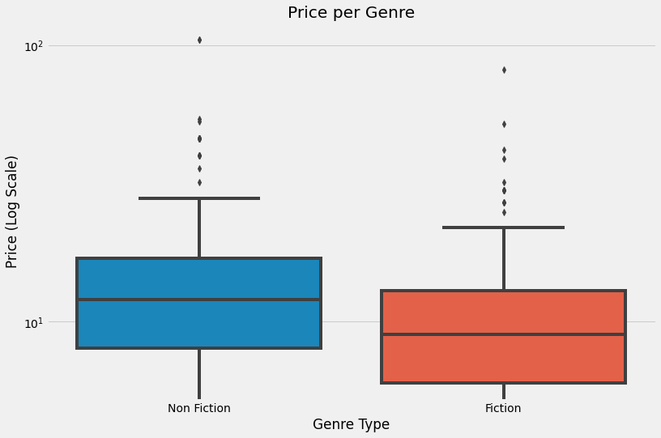

```python
most_expensive_book = amz_df.loc[amz_df.Price > 100]
median_vals = amz_df.groupby('Genre').median()

fig, ax = plt.subplots(figsize=(12,8))

sns.boxplot(x = "Genre", y = "Price", data = amz_df, ax = ax)
ax.set_yscale('Log')
ax.set_ylabel('Price (Log Scale)')
ax.set_xlabel('Genre Type')
ax.set_title('Price per Genre')
fig.show()
```

- Non Fiction books tend to be a more expensive
- Median for Non Fiction books is 12€, 9€ for Fiction
- Both have outliers that lie above the max whisker, and there is one bestseller that costs more than 100€ in the Non Fiction section

#### What is the Reviews Distribution for the Books?

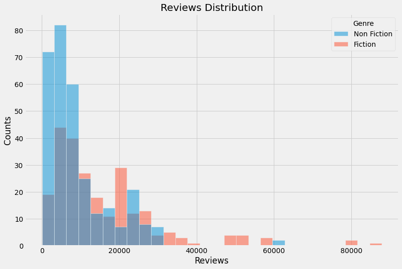

```python
# Reviews Distribution

fig, ax = plt.subplots(figsize = (12,8))
sns.histplot(x = 'Reviews', hue = 'Genre', data = amz_df, ax = ax)
ax.set_xlabel('Reviews')
ax.set_ylabel('Counts')
ax.set_title('Reviews Distribution')
fig.show()
```

- Most Reviews are in the Range of 0 - 30,000
- Fiction Books have Reviews that cross 80,000

#### What Is the Number of Books Per Rating?

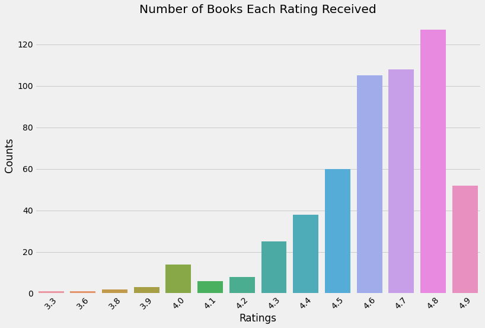

```python
# Count of books based per Rating

fig, ax = plt.subplots(figsize = (12,8))
sns.barplot(amz_df['User Rating'].value_counts().index, amz_df['User Rating'].value_counts(), ax = ax)
ax.set_xlabel('Ratings')
ax.set_ylabel('Counts')
ax.set_title('Number of Books Each Rating Received')
plt.xticks(rotation = 45)
fig.show()
```

- Most of the ratings for bestselling books are in the range of 4.5 - 4.9

#### Which Year Has the Highest User Rating?

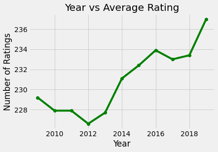

```python
# Year with Highest Ratings

amz_df.groupby('Year')['User Rating'].sum().plot(marker = 'o', c = 'g')
plt.title('Year vs Average Rating')
plt.xlabel('Year')
plt.ylabel('Number of Ratings');
```

#### Which Year Has the Highest Reviews?

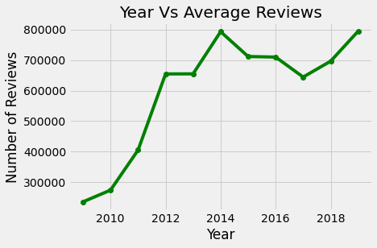

```python
# Year with Highest Reviews

amz_df.groupby('Year')['Reviews'].sum().plot(marker = 'o', c = 'g')
plt.title('Year Vs Average Reviews')
plt.xlabel('Year')
plt.ylabel('Number of Reviews')
```

#### What is the Price Variation Through Time?

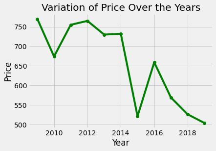

```python
# Price Variation through the Time

amz_df.groupby('Year')['Price'].sum().plot(marker = 'o', c = 'g')
plt.title('Variation of Price Over the Years')
plt.xlabel('Year')
plt.ylabel('Price')
```

- Before 2010 the prices were at its peak and in 2010 there was a drop.
- There was a rise till 2012 with a steep decline from 2014 to 2015.
- There was a significant rise in 2016, but after that onwards there has been a steady decline in the prices.

#### What Were the Best Books over the Decade?

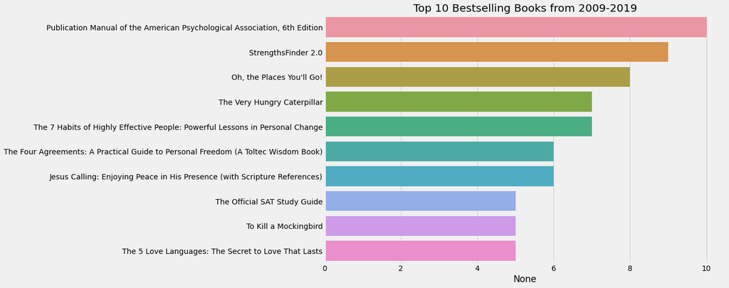

```python
best_books = amz_df['Name'].value_counts()[:10]

fig, ax = plt.subplots(figsize=(12,8))
sns.barplot(y=best_books.index, x=best_books, ax=ax)
ax.set_xlabel('None')
ax.set_title('Top 10 Bestselling Books from 2009-2019')
fig.show()
```

- The Best Book over the Decade was 'Publication Manual of the American Psychological Association, 6th Edition'

#### What Are the Highest Reviewed Books?

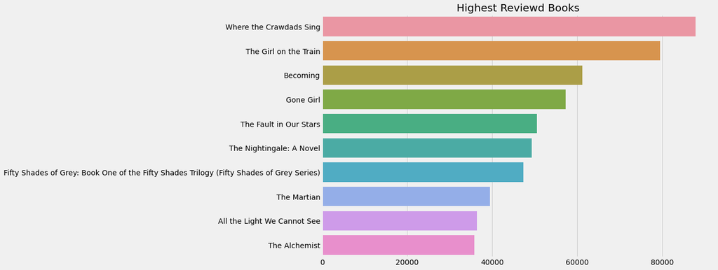

```python
# Top Reviewed Books

top_reviews = amz_df.nlargest(20, ['Reviews'])

fig, ax = plt.subplots(figsize = (12,8))
sns.barplot(top_reviews['Reviews'], top_reviews['Name'], ax = ax)
ax.set_xlabel(None)
ax.set_ylabel(None)
ax.set_title('Highest Reviewd Books')
fig.show()
```

- The Highest Reviewed Book was 'Where the Crawdads Sing' with about 85,000 reviews

#### What Are the Lowest Reviewed Books?

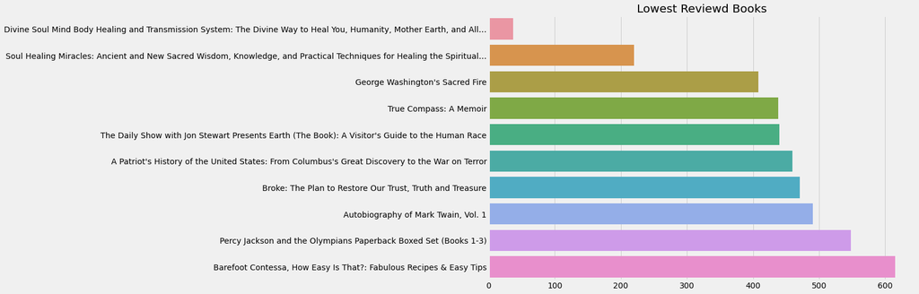

```python
# Lowest Reviewed Books

lowest_reviews = amz_df.nsmallest(10, ['Reviews'])

fig, ax = plt.subplots(figsize = (12,8))
sns.barplot(lowest_reviews['Reviews'], lowest_reviews['Name'], ax = ax)
ax.set_xlabel(None)
ax.set_ylabel(None)
ax.set_title('Lowest Reviewd Books')
fig.show()
```

- The Lowest Reviewed Book was 'Divine Soul Mind Body Healing and Transmission System: The Divine Way to Heal...' with less than 100 reviews

#### What Are the Worst Rated Books?

```python
# Worst Rated Books

worst = amz_df.sort_values('User Rating').head(10)
worst
```

|  | Name | Author | User Rating | Reviews | Price | Year | Genre |
| --- | --- | --- | --- | --- | --- | --- | --- |
| 353 | The Casual Vacancy | J.K. Rowling | 3.3 | 9372 | 12 | 2012 | Fiction |
| 132 | Go Set a Watchman: A Novel | Harper Lee | 3.6 | 14982 | 19 | 2015 | Fiction |
| 106 | Fifty Shades of Grey: Book One of the Fifty Sh... | E L James | 3.8 | 47265 | 14 | 2012 | Fiction |
| 107 | Fifty Shades of Grey: Book One of the Fifty Sh... | E L James | 3.8 | 47265 | 14 | 2013 | Fiction |
| 393 | The Goldfinch: A Novel (Pulitzer Prize for Fic... | Donna Tartt | 3.9 | 33844 | 20 | 2014 | Fiction |
| 22 | Allegiant | Veronica Roth | 3.9 | 6310 | 13 | 2013 | Fiction |
| 392 | The Goldfinch: A Novel (Pulitzer Prize for Fic... | Donna Tartt | 3.9 | 33844 | 20 | 2013 | Fiction |
| 364 | The Elegance of the Hedgehog | Muriel Barbery | 4.0 | 1859 | 11 | 2009 | Fiction |
| 137 | Gone Girl | Gillian Flynn | 4.0 | 57271 | 9 | 2014 | Fiction |
| 136 | Gone Girl | Gillian Flynn | 4.0 | 57271 | 10 | 2013 | Fiction |

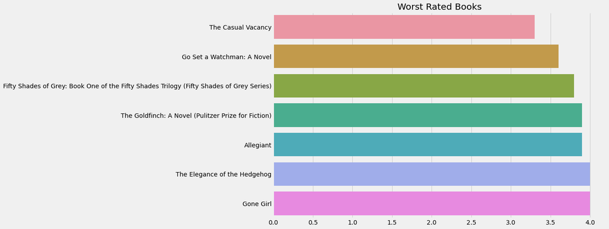

```python
# Visualize the Worst Rated Books

fig, ax = plt.subplots(figsize = (12,8))
sns.barplot(y = worst['Name'], x = worst['User Rating'], ax = ax)
ax.set_xlabel(None)
ax.set_ylabel(None)
ax.set_title('Worst Rated Books')
fig.show()
```

- The worst rated book is 'The Casual Vacancy' by J.K. Rowling with User Ratings of 3.3.

#### What Are the Most Expensive Books?

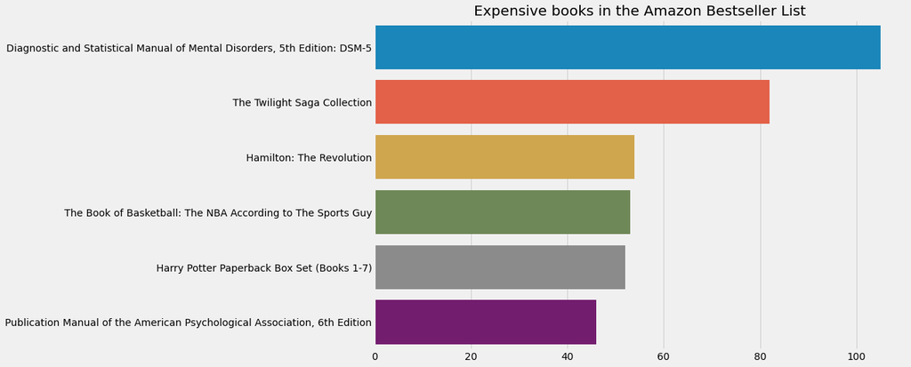

```python
# Most Expensive Books

top_expensive = amz_df.drop(amz_df[amz_df['Price'] < 1].index).sort_values('Price', ascending = False).head(10)

fig, ax = plt.subplots(figsize = (12,8))
sns.barplot(y = top_expensive['Name'], x = top_expensive['Price'], ax = ax)
ax.set_xlabel(None)
ax.set_ylabel(None)
ax.set_title('Expensive books in the Amazon Bestseller List')
fig.show()
```

- The most expensive book is 'Diagnostic and Statistical Manual of Mental Disorders' and costs about 105€

#### What Are the Cheapest Books?

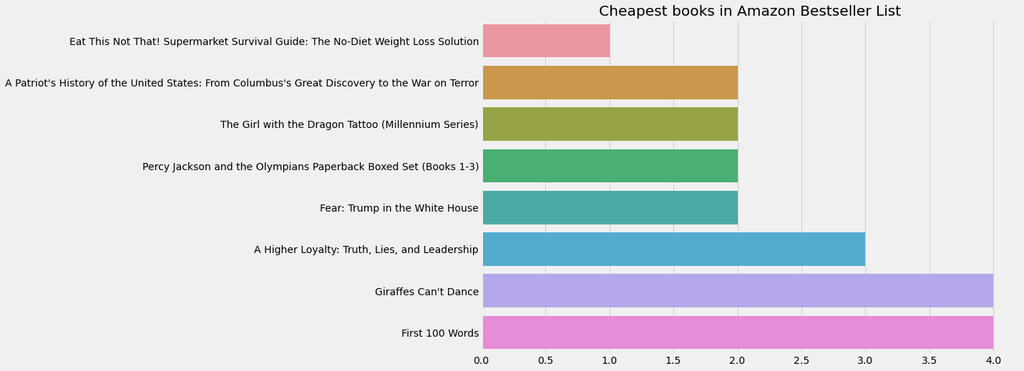

```python
# Cheapest Books

cheapest = amz_df[-amz_df['Price'].isin([0])].sort_values('Price').head(10)

fig, ax = plt.subplots(figsize = (12,8))
sns.barplot(x = cheapest['Price'], y = cheapest['Name'], ax = ax)
ax.set_xlabel(None)
ax.set_ylabel(None)
ax.set_title('Cheapest books in Amazon Bestseller List')
fig.show()
```

- The cheapest book is 'Eat This Not That! Supermarket Survival Guide: The No-Diet Weight Loss Solution' and costs 1€

#### What Are the Best 10 Free Books?

```python
# Top 10 Free Books

amz_df.drop(amz_df[amz_df['Price'] > 0].index).sort_values('User Rating', ascending = False).head(10)
```

|  | Name | Author | User Rating | Reviews | Price | Year | Genre |
| --- | --- | --- | --- | --- | --- | --- | --- |
| 219 | Little Blue Truck | Alice Schertle | 4.9 | 1884 | 0 | 2014 | Fiction |
| 42 | Cabin Fever (Diary of a Wimpy Kid, Book 6) | Jeff Kinney | 4.8 | 4505 | 0 | 2011 | Fiction |
| 71 | Diary of a Wimpy Kid: Hard Luck, Book 8 | Jeff Kinney | 4.8 | 6812 | 0 | 2013 | Fiction |
| 358 | The Constitution of the United States | Delegates of the Constitutional | 4.8 | 2774 | 0 | 2016 | Non Fiction |
| 381 | The Getaway | Jeff Kinney | 4.8 | 5836 | 0 | 2017 | Fiction |
| 505 | To Kill a Mockingbird | Harper Lee | 4.8 | 26234 | 0 | 2013 | Fiction |
| 506 | To Kill a Mockingbird | Harper Lee | 4.8 | 26234 | 0 | 2014 | Fiction |
| 507 | To Kill a Mockingbird | Harper Lee | 4.8 | 26234 | 0 | 2015 | Fiction |
| 508 | To Kill a Mockingbird | Harper Lee | 4.8 | 26234 | 0 | 2016 | Fiction |
| 116 | Frozen (Little Golden Book) | RH Disney | 4.7 | 3642 | 0 | 2014 | Fiction |

#### Who Are the Most Popular Authors?

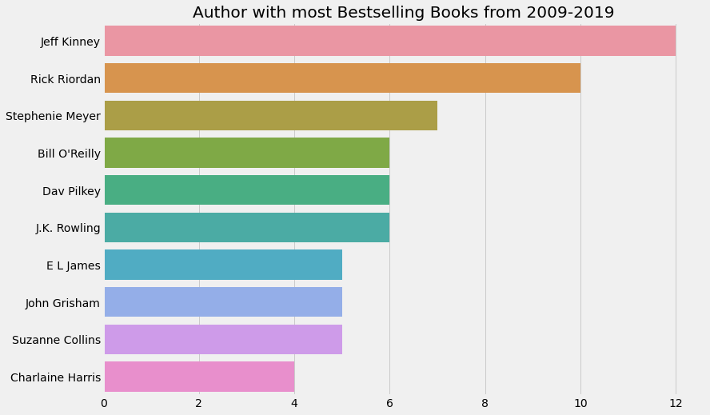

```python
best_author = amz_df[['Name', 'Author']].groupby('Author').agg('nunique').nlargest(10, columns='Name')

fig, ax = plt.subplots(figsize = (12,8))
sns.barplot(x = best_author.Name, y = best_author.index, ax = ax)
ax.set_xlabel(None)
ax.set_ylabel(None)
ax.set_title('Author with most Bestselling Books from 2009-2019')
fig.show()
```